# Homework #2: Resampling

Siyu Jian / sj9va

Due: Wed Feb 24 | 10:55am

**SYS 4582/6018 | Spring 2021 | University of Virginia**

# Required R packages and Directories

```r
data.dir = 'https://mdporter.github.io/SYS6018/data/' # data directory
library(R6018)     # functions for SYS-6018
library(tidyverse) # functions for data manipulation
library(boot)
library(broom)
library(splines)
```

# Problem 1: Bootstrapping

Bootstrap resampling can be used to quantify the uncertainty in a fitted curve.

## a. Create a set of functions to generate data from the following distributions:

$$\begin{align*}
X &\sim \mathcal{U}(0, 2) \qquad \text{Uniform in $[0,2]$}\\
Y &= 1 + 2x + 5\sin(5x) + \epsilon \\
\epsilon &\sim \mathcal{N}(0,\, \sigma=2.5)
\end{align*}$$

Add solution here

```r
library(dplyr)
sim_x <- function(n) runif(n,0,2)
yfunc <- function(x) 1 + 2*x + 5*sin(5*x)
sim_y <- function(x,sd){
  n = length(x)
  yfunc(x) + rnorm(n,sd = sd)
}

dataSet <- function(n, sd){
  tibble(x=sim_x(n),
         y= sim_y(x,sd))
}
```

## b. Simulate $n=100$ realizations from these distributions. Produce a scatterplot and draw the true regression line $f(x) = E[Y \mid X=x]$. Use `set.seed(211)` prior to generating the data.

Add solution here

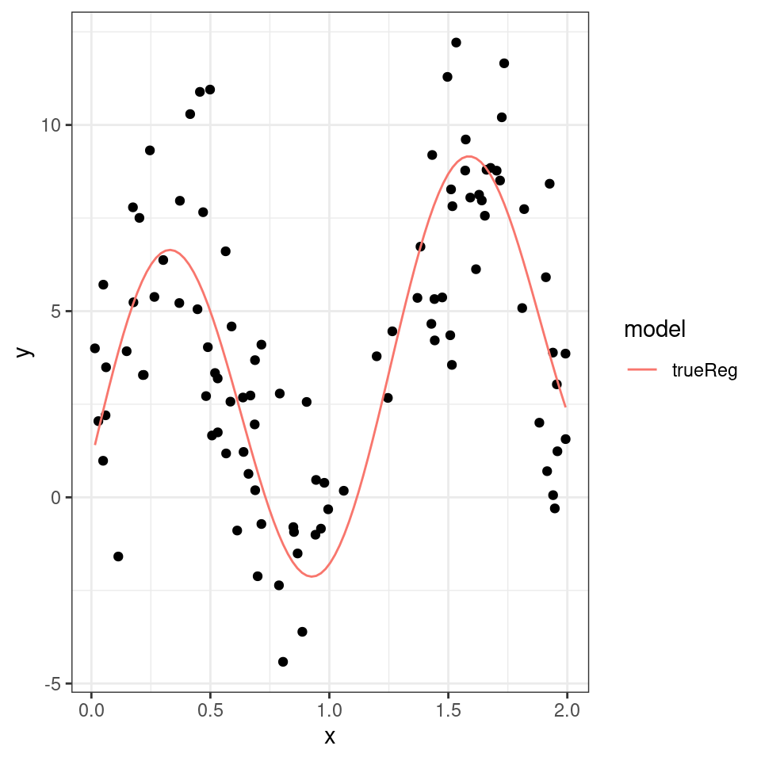

```r
n  = 100
sd = 2.5
set.seed(211)

data_train = dataSet(n,sd)

ggplotCanv <- ggplot(data_train, aes(x,y)) + geom_point()

ggplotCanv+
  stat_function(fun = yfunc,aes(colour = "trueReg"))+
  scale_color_discrete(name="model")
```

## c. Fit a 5th degree polynomial. Produce a scatterplot and draw the *estimated* regression curve.

Add solution here

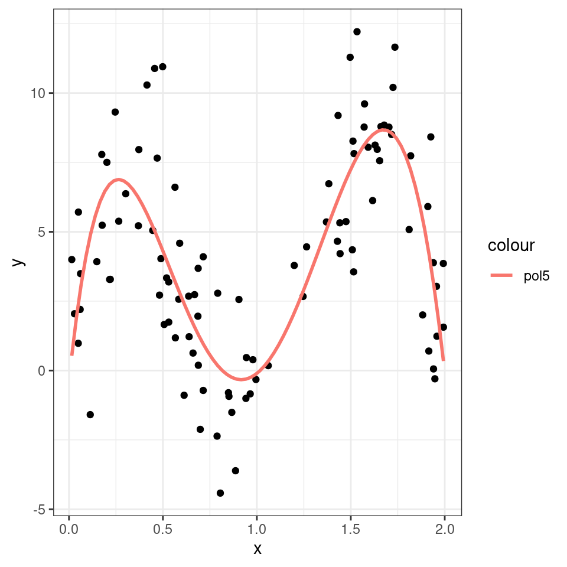

```r
ggplotCanv +
  geom_smooth(method = "lm",formula = "y~poly(x,5)", se=FALSE, aes(color ="pol5"))
```

## d. Draw 200 bootstrap samples, fit a 5th degree polynomial to each bootstrap sample, and make predictions at `eval.pts = seq(0, 2, length=100)`

- Set the seed (use `set.seed(212)`) so your results are reproducible.
- Produce a scatterplot and add the 200 bootstrap curves

Add solution here

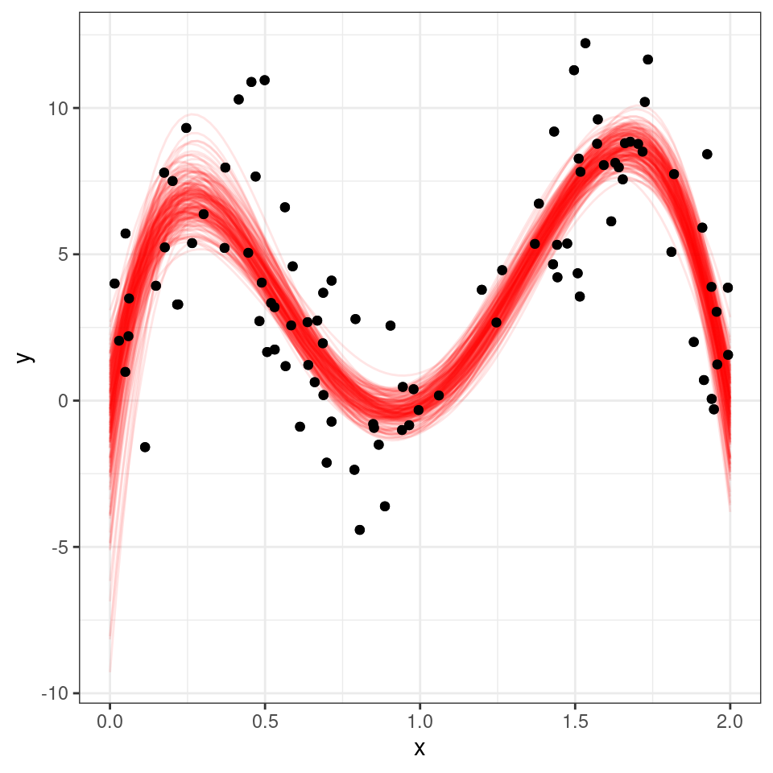

```r
M = 200
data_eval = tibble(x=seq(0,2,length=100))
YHAT = matrix(NA, nrow(data_eval),M)

set.seed(212)
for (m in 1:M) {
  ind = sample(n, replace = TRUE)
  data.boot = data_train[ind,]
  m_boot = lm(y~poly(x,5),data = data.boot)
  pridicVal = predict(m_boot,newdata = data_eval)
  YHAT[,m] = pridicVal

}

data_fit = as_tibble(YHAT) %>%
  bind_cols(data_eval) %>%
  gather(simulation, y, -x)

ggplotCanv +
  geom_line(data=data_fit, color="red", alpha=.10, aes(group=simulation)) +
  geom_point()
```

## e. Calculate the pointwise 95% confidence intervals from the bootstrap samples. That is, for each $x \in {\rm eval.pts}$, calculate the upper and lower limits such that only 5% of the curves fall outside the interval at $x$.

- Remake the plot from part *c*, but add the upper and lower boundaries from the 95% confidence intervals.

Add solution here

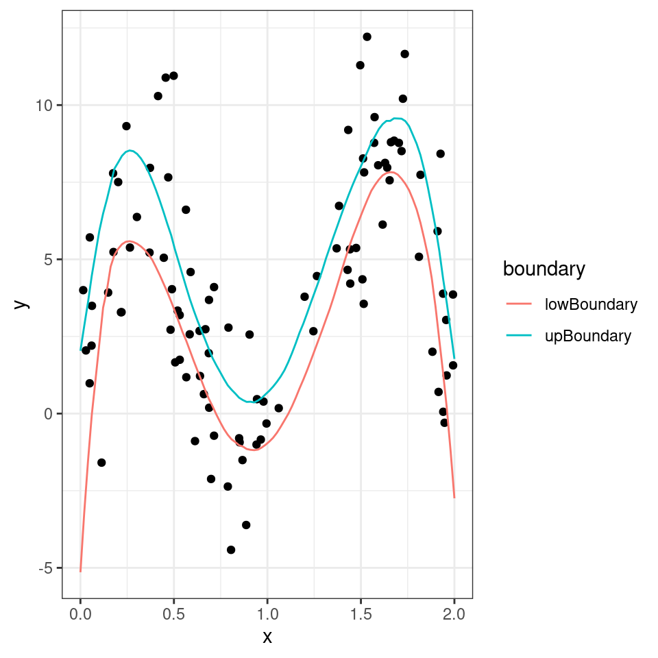

```r
# loop on the boundary and get the confidence interval bounday for the each dataset
confidentBoundary = tibble(upBoundary=numeric(),lowBoundary=numeric())

for (data_index in 1:nrow(data_eval)){
  test_set.singleX = tibble(x=1:M,y=YHAT[data_index,])
  confidenceVal = quantile(test_set.singleX$y,probs = c(0.025,0.975))
  confidentBoundary = add_row(confidentBoundary,lowBoundary = confidenceVal[[1]],upBoundary=confidenceVal[[2]])
}

data_boundary = as_tibble(confidentBoundary) %>%
  bind_cols(data_eval) %>%
 gather(boundary,y,-x)
ggplotCanv +
  geom_line(data = data_boundary,aes(x=x,colour=boundary))
```

# Problem 2: V-Fold cross-validation with $k$ nearest neighbors

Run 10-fold cross-validation on the data generated in part 1b to select the optimal $k$ in a k-nearest neighbor (kNN) model. Then evaluate how well cross-validation performed by evaluating the performance on a large test set. The steps below will guide you.

## a. Use $10$-fold cross-validation to find the value of $k$ (i.e., neighborhood size) that provides the smallest cross-validated MSE using a kNN model.

- Search over $k=3,4,\ldots, 50$.
- Use `set.seed(221)` prior to generating the folds to ensure the results are replicable.
- Show the following:
  - the optimal $k$ (as determined by cross-validation)
  - the corresponding estimated MSE
  - produce a plot with $k$ on the x-axis and the estimated MSE on the y-axis (optional: add 1-standard error bars).
- Notation: *v*-fold cross-validation; *k*-nearest neighbor. Don’t get yourself confused.

Add solution here

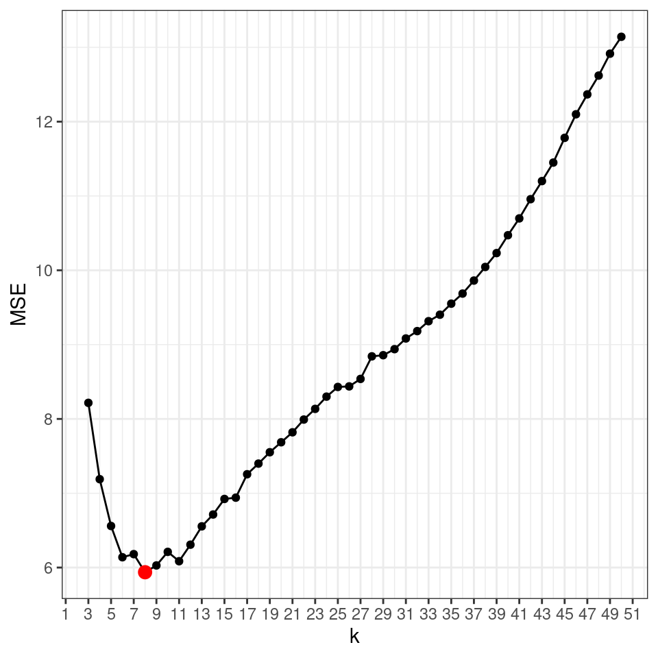

```r
library(FNN)
library(knitr)
set.seed(221)
n.folds = 10 # asign the K.fold vallue
fold = sample(rep(1:n.folds, length=n))
k.knn = seq(3,50,by=1) # k value for the knn

# function used for evalute the knn mse
knn_eval <- function(data_train,data_test,kseq=seq(3,50,by=1)){
  MSE = numeric(length(kseq))
  EDF = numeric(length(kseq))
  # get the mse for each k
  for (i in 1:length(kseq)) {
    k = kseq[i]
    #get the test dataset residual
    knn.test = knn.reg(data_train[,'x', drop=FALSE],
                       y = data_train$y,
                       test=data_test[,'x', drop=FALSE],
                       k=k)
    EDF[i] = nrow(data_train)/k
    r.test = data_test$y-knn.test$pred # residuals on test data
    MSE[i] = mean(r.test^2)          # test MSE
  }
  tibble(k = kseq, mse = MSE, edf = EDF)
}

results = tibble()

for (j in 1:n.folds) {
  val = which(fold == j)
  train = which(fold != j)

  n.val = length(val)
  results_j = knn_eval(data_train[train,],data_train[val,],kseq = k.knn)
  results = bind_rows(results,results_j %>% mutate(n.val,fold = j))
}


#results %>% filter(k==8) %>% mutate(sse = mse*n.val) %>% mutate(mse_sum = sum(sse)) %>%mutate(mse_sum/nrow(data_train)) %>%kable()

# proprocess before  plot
# MSE will be the mean of the 10 fold for each k value
R = results %>%
  mutate(sse = mse*n.val) %>%
  group_by(k) %>%
  summarise(Kv = n(), sse = sum(sse),MSE = sse/nrow(data_train),
            mse_mn=mean(mse),mse_sd = sd(mse),se = mse_sd/sqrt(Kv))

R %>%
  ggplot(aes(k,MSE)) + geom_point() + geom_line() +
  # geom_errorbar(aes(ymin=MSE-se, ymax=MSE+se), width=.2,position=position_dodge(.5))+
  geom_point(data=. %>% filter(MSE==min(MSE)), color="red", size=3) +
  scale_x_continuous(breaks=seq(1,60,by=2))
```

```r
# kable(R)
```

the value of k (i.e., neighborhood size) that provides the smallest cross-validated MSE :

```r
finalRes.a = R%>%filter(MSE==min(MSE))
tibble(k=finalRes.a$k,min_mse = finalRes.a$MSE)
```

| k | min_mse |
| --- | --- |
| 8 | 5.937 |

## b. The $k$ (number of neighbors) in a kNN model determines the effective degrees of freedom *edf*. What is the optimal *edf*? Be sure to use the correct sample size when making this calculation. Produce a plot similar to that from part *a*, but use *edf* (effective degrees of freedom) on the x-axis.

Add solution here

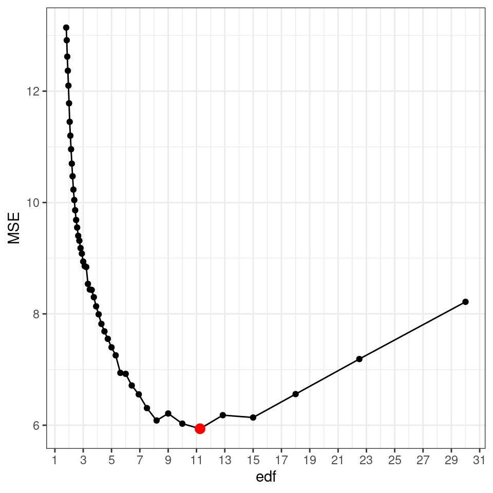

```r
# proprocess before  plot
Redf = results %>%
  mutate(sse = mse*n.val) %>%
  group_by(edf) %>%
  summarise(Kv = n(), sse = sum(sse),MSE = sse/nrow(data_train),
            mse_mn=mean(mse),mse_sd = sd(mse),se = mse_sd/sqrt(Kv))


Redf %>%
  ggplot(aes(edf,MSE)) + geom_point() + geom_line() +
  geom_point(data=. %>% filter(MSE==min(MSE)), color="red", size=3)+
  scale_x_continuous(breaks=seq(1,60,by=2))
```

The optimal edf is :

```r
finalRes.b = Redf %>%filter(MSE==min(MSE))

kable(tibble(edf = finalRes.b$edf, min_mse = finalRes.b$MSE))
```

| edf | min_mse |
| --- | --- |
| 11.25 | 5.937 |

## c. After running cross-validation, a final model fit from *all* of the training data needs to be produced to make predictions. What value of $k$ would you choose? Why?

| k | min_mse |
| --- | --- |
| 8 | 5.937 |

## d. Now we will see how well cross-validation performed. Simulate a test data set of $50000$ observations from the same distributions. Use `set.seed(223)` prior to generating the test data.

- Fit a set of kNN models, using the full training data, and calculate the mean squared error (MSE) on the test data for each model. Use the same $k$ values in *a*.
- Report the optimal $k$, the corresponding *edf*, and MSE based on the test set.

Add solution here

- kNN k regression

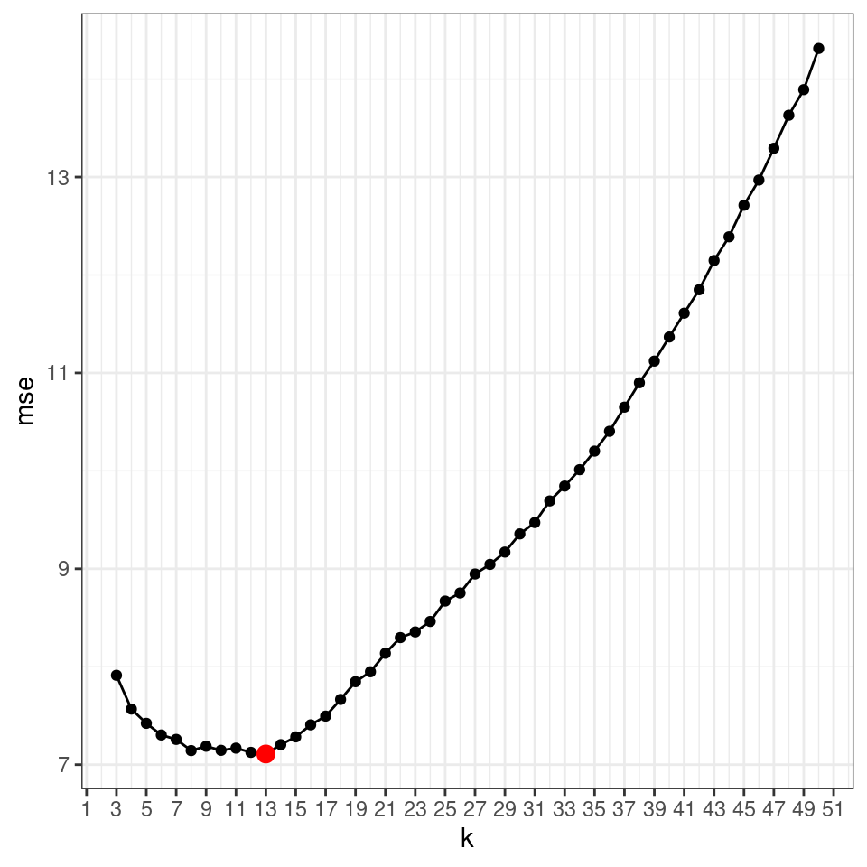

```r
#, fig.width=15,fig.height=10
set.seed(223)
testdata = dataSet(50000,sd)

results.d = knn_eval(data_train,testdata,kseq = k.knn)

results.d %>% ggplot(aes(k,mse))+ geom_point() + geom_line() +
  geom_point(data=. %>% filter(mse==min(mse)), color="red", size=3)+
  scale_x_continuous(breaks=seq(1,60,by=2))
```

- Optimal k result:

| k | mse | edf |
| --- | --- | --- |
| 13 | 7.109 | 7.692 |

## e. Plot both the cross-validation estimated and (true) error calculated from the test data on the same plot. See Figure 5.6 in ISL (pg 182) as a guide.

- Produce two plots: one with $k$ on the x-axis and one with *edf* on the x-axis.
- Each plot should have two lines: one from part *a* and one from part *d*

Add solution here

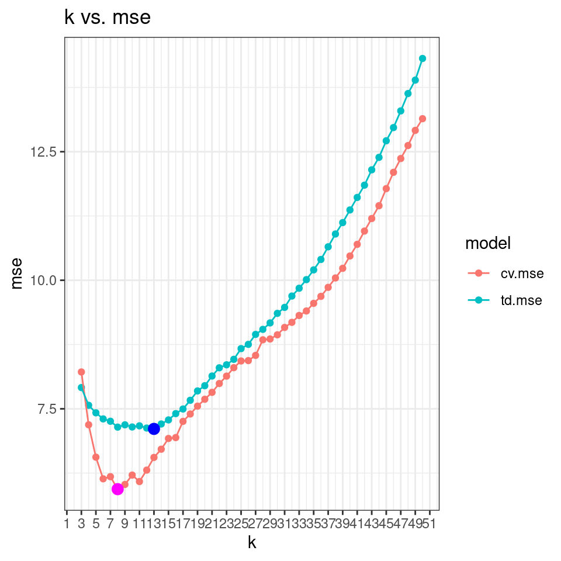

```r
#maybe the question is just just merge the two plot from a. and d. ????
result.e = tibble(k = k.knn,cv.mse = R$MSE, td.mse = results.d$mse)

result.e.merge = result.e %>% gather(model,mse,-k)

#kable(result.e.merge %>% filter(result.e.merge$model == "cv.mse") %>% filter(mse == min(mse)))

ggplot(data = result.e.merge, aes(x=k,y=mse, colour = model)) + geom_point()+ geom_line() +
  geom_point(data=. %>% filter(result.e.merge$model == "cv.mse") %>% filter(mse == min(mse)), color="magenta", size=3)+
  geom_point(data=. %>% filter(result.e.merge$model == "td.mse") %>% filter(mse == min(mse)), color="blue", size=3)+
  scale_x_continuous(breaks=seq(1,60,by=2)) +
  ggtitle("k vs. mse")
```

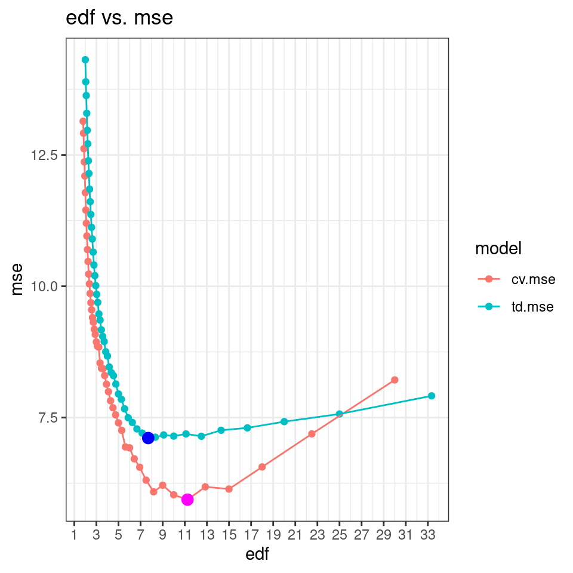

```r
result.e2 = tibble(model = "cv.mse",edf = Redf$edf, mse = Redf$MSE)
result.e2 = add_row(result.e2,model = "td.mse",edf = results.d$edf,mse = results.d$mse)

ggplot(data = result.e2, aes(x = edf, y=mse, colour = model)) + geom_point() + geom_line() +
  geom_point(data=. %>% filter(result.e2$model == "cv.mse") %>% filter(mse == min(mse)), color="magenta", size=3)+
  geom_point(data=. %>% filter(result.e2$model == "td.mse") %>% filter(mse == min(mse)), color="blue", size=3)+
  scale_x_continuous(breaks=seq(1,60,by=2)) +
  ggtitle("edf vs. mse")
```

## f. Based on the plots from *e*, does it appear that cross-validation worked as intended? How sensitive is the choice of $k$ on the resulting test MSE?

- Based on the plots from e, does it appear that cross-validation worked as intended?

- How sensitive is the choice of k on the resulting test MSE?

When k is small, the test MSE will decrease when k increase. Close to the minimum mse k area, the mse is less sensitive to the k value. When k increase, the mse value does not change much. In large K area, when k increase, the mse also increase.